# Assignment 2

**CS283 Computer Vision, Harvard University, Fall 2019**

**Due Wednesday, Oct. 9, at 5:00pm**

Name: Natalia María Pacheco-Tallaj

$\def\vO{{\bf O}} \def\vP{{\bf P}} \def\vp{{\bf p}} \def\vx{{\bf x}} \def\vt{{\bf t}} \def\vl{{\bf l}} \def\vm{{\bf m}} \def\vX{{\bf X}} \def\mS{{\bf S}} \def\mT{{\bf T}} \def\mH{{\bf H}} \def\mA{{\bf A}} \def\mM{{\bf M}} \def\mP{{\bf P}} \def\tx{{\tilde{\bf x}}} \def\ta{{\tilde{\bf a}}} \def\tb{{\tilde{\bf b}}} \def\tc{{\tilde{\bf c}}} \def\hn{{\bf \hat{n}}} \def\hv{{\bf \hat{v}}} \def\hh{{\bf \hat{h}}} \def\vh{{\bf h}} \def\vs{{\bf s}} \def\hs{{\bf \hat{s}}} \def\vf{{\bf f}} \def\vPhi{{\bf \Phi}} %\def\vphi{{\mbox{\boldmath$\phi$}}} \def\vphi{{\boldsymbol{\phi}}} \def\vF{{\bf F}} \def\real{{\text{real}}}$

This problem set explores structure-from-motion and linear filtering. As usual, the assignment will be submitted via Canvas and formatted according to the guidelines. The **Hints and Information** section is especially helpful this week.

As always, your submission must follow the Submission Guidelines and take the form of an HTML version of the notebook (`.html`), and a ZIP containing your Jupyter notebook (`.ipynb`), and accompanying `./data` and `./src` and possibly `./img` folders. (The `./src` folder will be empty this week.)

In cases where we ask for a function to be implemented, you may also implement additional helper functions either inside the function itself (locally) or outside it (globally). If you do it globally, please implement the function in the same cell.

```python
# Run this cell (only once) to install the unzip command - if you already installed this for assignment 3, no need to reinstall
! sudo apt install unzip
```

[output not shown]

```python
# Extract required pset folders (make sure you ran the first cell first)
! unzip pset4.zip
```

```
Archive:  pset4.zip
   creating: data/
  inflating: data/checkeredbox1.jpg
  inflating: data/checkeredbox2.jpg
  inflating: data/checkeredbox3.jpg
  inflating: data/Cameraman_PeriodicNoise.tif
  inflating: data/checkeredbox4.jpg
  inflating: data/checkeredbox5.jpg
  inflating: data/checkeredbox6.jpg
  inflating: data/checkeredbox7.jpg
  inflating: data/corners.pickle
  inflating: img/GaussianBandReject.eps
  inflating: img/GaussianBandReject.pdf
  inflating: img/GaussianBandReject.png
```

```python
# Import any required libraries here
import cv2                # OpenCV
import numpy as np        # numpy
import pickle
from mpl_toolkits.mplot3d.art3d import Poly3DCollection
import scipy.optimize

# Use this line to make matplotlib plot inline (only need to call it once when importing matplotlib)
# For 3D plotting, it can be helpful to call %matplotlib notebook, but note that if you want to switch back to inline,
# you'll need to restart the kernel
%matplotlib inline

import matplotlib.pyplot as plt
# Modify this line to adjust the displayed plot size. You can also call
# it with different parameters before specific plots.
plt.rcParams['figure.figsize'] = [10, 10]
```

## Question 1 (15 points)

The assignment's data folder contains seven parallel-projection images of a checkered box. It also contains a `.pickle` file with the pixel coordinates of $n=84$ corners detected in each image as an $n\times 2\times 7$ array named `corners`. (For example, `corners[j,:,i]` gives the $(x,y)$-coordinates of $\tilde{\bf x}_j^i$, the $j^{th}$ point in the $i^{th}$ image.)

**a.** Use the factorization algorithm to recover the seven affine cameras and world points from these pixel coordinates. Write a function `affine_factorization(x)` that takes an $n\times 2\times m$ array of pixel coordinates, corresponding to $n$ world points observed in $m$ views, and returns $2m\times3$ and $2m\times 1$ matrices `M` and `T` that describe the $m$ affine cameras, and an $n\times 3$ matrix `X` with the coordinates of the $n$ world points. Plot the recovered points using the commands

```
plt.figure()
ax = plt.axes(projection='3d')
ax.scatter(X[:,0],X[:,1],X[:,2])
```

Include your plot. Are angles and/or parallelism presented correctly in this reconstruction? Why or why not?

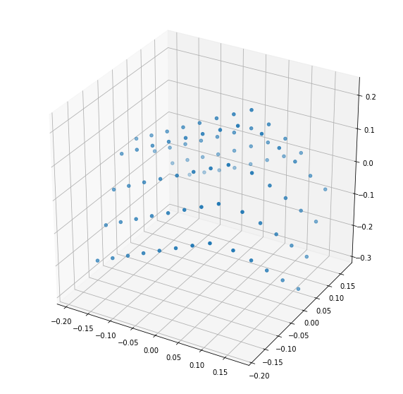

```python
data = pickle.load(open('./data/corners.pickle', 'rb'))

# corners: zeroth axis is which out of the 84 pts
# first axis is which out of the x or y coordinate
# second axis is which of the images
corners = data['corners']

def affine_factorization(x):
    # swap axes so 0th axis is image num, 1st axis is x or y coord
    # then average along 2nd axis which is now iterating over the pts
    t = np.average(x.swapaxes(0,2), axis=2)
    normalized_x = x - np.array([t.swapaxes(0,1)]*len(x))

    # reshape reads elements with last axis index changing the fastest
    # and fills new array row first. Height should be 2*(# of images),
    # width should be # of pts
    W = normalized_x.swapaxes(0,2).reshape((2 * len(x[0][0]) ,len(x)))

    U,D,VT = np.linalg.svd(W)

    # M = first three columns of U by first 3 singular values
    # X is first 3 rows of VT i.e. first 3 columns of V
    M = U[:,:3] * D[:3]
    X = VT[:3].transpose()
    return (M,t,X)

M, t, X = affine_factorization(corners)

plt.figure()
ax = plt.axes(projection='3d')
ax.scatter(X[:,0],X[:,1],X[:,2])
```

### Answer:

Parallelism is presented correctly here, but angles look more obtuse than they do in the photos. The reason parallelism is preserved is because if we parallel project two parallel lines, we're drawing a line through each point that is orthogonal to the projection plane. Thus we have two parallel planes orthogonal to the projection plane and containing each of the parallel lines, and the images of those lines in the parallel projection are the intersection of these planes with the projection plane, which must be parallel. However anagles need not be preserved. I think they'd only get preserved if the angles lie on a plane that's parallel to the projection plane, by a similar explanation as described above. Otherwise, one way to show that angles aren't preserved is to consider affine ambiguity: note that our solution of $X$ only works up to some arbitrary invertible affine transformation, and affine transformations preserve parallelism but not necessarily angles.

**b.** One measure of the accuracy of the reconstruction is the root-mean-square (RMS) reprojection error

$ E_{rms}=\left(\frac{1}{nm}\sum_{ij} ||\tilde{\vx}_j^i - (\mM^i\vX_j+\vt^i)||^2\right)^{1/2} $

Compute and report the RMS reprojection error for your reconstruction.

```python
M, t, X = affine_factorization(corners)

# matrix MX + t
WW = np.dot(M, X.transpose()) + np.transpose([t.flatten()])
realvalues = corners.swapaxes(0,2).reshape((2 * len(corners[0][0]) ,len(corners)))

n, _, m = corners.shape

E = np.linalg.norm(realvalues - WW) / np.sqrt(n * m)
print("The error is {}".format(E))
```

```
The error is 1.4205043343920813
```

**c. Bonus Question (Earn up to 10 points extra)** Upgrade the reconstruction by enforcing constraints corresponding to 'square pixels and zero skew'. Write a function `upgrade(Min,Xin)` (see the Hints and Information below) that finds the $3\times 3$ matrix $\mA$ that minimizes

$ \sum_{i=1}^m\left(\left(\vm_{i1}^\top\mA\mA^\top\vm_{i2}\right)^2 + \left(\vm_{i1}^\top\mA\mA^\top\vm_{i1}-\vm_{i2}^\top\mA\mA^\top\vm_{i2}\right)^2\right) $

and uses this matrix to transform both `Xin` and `Min` appropriately. The function should also apply a scale change to (`Xin`, `Min`) such that the average distance from a world point to the world origin is $\sqrt{3}$.

Plot the points using the same commands as in part (a), and submit your plot. Compute and report the RMS reprojection error for the upgraded reconstruction. How does it compare to that of part (b) and why?

### Answer:

Its the same error. This is because the error is determined by the image $MX$ of the calculated 3D points under the calculated 3D matrices. If $M$ is replaced by $\frac{1}{c}MA$ where $c$ is some scale factor and $A$ a full rank $3\times 3$ matrix, and $X$ is replaced by $cA^{-1}X$, then the error will still depend on the image of the collection of points under the collection of camera matrices $\frac{1}{c}MAcA^{-1}X = MAA^{-1}X = MX$, so the error will be the same. This is because of the affine ambiguity of the reconstruction--we've only recovered $M,X$ up to multiplication by an invertible transformation, in this case $\frac{1}{c}A$, but the whole family of possible solutions for the matrices and 3D points will give the same projections, and thus the same error when measuring the deviation from the input images!

```
The error is 1.4205043343920802
```

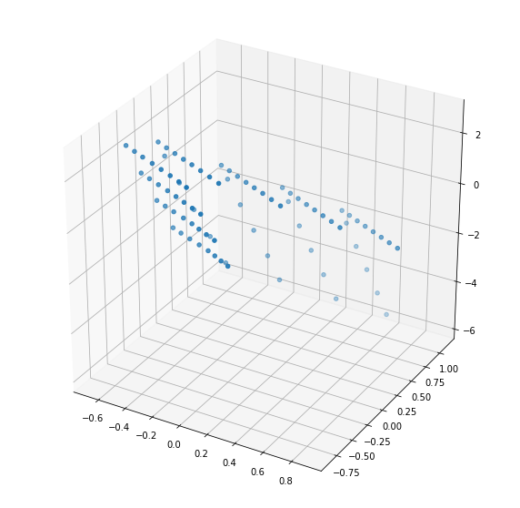

```python
Min, t, Xin = affine_factorization(corners)
n,_,m = corners.shape

def myfun(A):
    A = np.reshape([A],(3,3))
    F = []
    # maybe there's a nice way to do this without iterating, but we only have 7 images
    # so I will iterate through them and that should be fine
    for i in range(m):
        F.append(
            (np.dot(np.dot(M[2*i], A), np.dot(np.transpose(A), np.transpose([M[2*i+1]])))**2 +
            (np.dot(np.dot(M[2*i], A), np.dot(np.transpose(A), np.transpose([M[2*i + 1]])))
            - np.dot(np.dot(M[2*i+1], A), np.dot(np.transpose(A), np.transpose([M[2*i+1]]))))**2)[0]
        )
    return F

A = scipy.optimize.least_squares(myfun,np.reshape(np.eye(3,3),(-1,9))[0])
A = A.x.reshape((3,3))

Mnew = np.dot(Min, A)
# compute Xnew as A^-1X, i.e. AXnew = X
Xnew = np.linalg.lstsq(A, Xin.transpose())[0].transpose()


davg = np.sum(np.sum(np.abs(Xnew)**2,axis=-1)**(1./2)) / float(len(Xnew))
Xnew = Xnew * np.sqrt(3) / davg
Mnew = Mnew * davg / np.sqrt(3)

plt.figure()
ax = plt.axes(projection='3d')
ax.scatter(Xnew[:,0],Xnew[:,1],Xnew[:,2])

WW = np.dot(Mnew, Xnew.transpose()) + np.transpose([t.flatten()])
realvalues = corners.swapaxes(0,2).reshape((2 * len(corners[0][0]) ,len(corners)))

E = np.linalg.norm(realvalues - WW) / np.sqrt(n * m)
print("The error is {}".format(E))
```

## Question 2 (10 points)

Let the $x^\mathrm{th}$ element of a vector $\vf$ be written $f(x)$. Furthermore, if $\vf$ is a vector with $M$ elements, let these elements be indexed by $x=0,\ldots,M-1$. Given an $M$-element vector $\vf$, we compute its discrete Fourier transform by expressing it in terms of a linear combination of $M$ complex-valued "basis vectors" $\{\vphi_u\},\ u=0,\ldots,M-1$ where the $x^\mathrm{th}$ element of the $u^\mathrm{th}$ basis vector is given by $\phi_u(x)=e^{j2\pi ux/M}=\cos{(2\pi ux/M)}+j\sin{(2\pi ux/M)}$. The linear combination is written $\vf=\sum_{u=0}^{M-1}F(u)\vphi_u$, and the set of $M$ coefficients $F(u)$—written in vector form as $\vF$—is referred to as the *discrete Fourier transform* (DFT) of $\vf$. The coefficients $F(u)$ are computed by projecting the vector $\vf$ onto a set of orthogonal vectors, and these projections can be written in matrix form as $\vF=\vPhi\vf$.

The DFT of a two-dimensional image $f(x,y),\ 0\le x\le M-1,\ 0\le y\le N-1$ can similarly be interpreted as the set of coefficients $F(u,v)$ defining a linear combination of orthogonal, complex-valued "basis images". The image is written

$\begin{equation} f(x,y)=\sum_{u=0}^{M-1}\sum_{v=0}^{N-1} F(u,v) I_{uv}(x,y), \end{equation} $

where the $(x,y)^\mathrm{th}$ element of the $(u,v)^\mathrm{th}$ basis image is given by

$ \begin{equation} I_{uv}(x,y)=e^{j2\pi(ux/M+vy/N)}. \end{equation} $

**a.** The real parts of the basis images $I_{uv}$ are sinusoids at various orientations and spatial frequencies. Restricting your attention to horizontally-oriented sinusoids (i.e., those with $v = 0$), which value of $u$ produces a basis image $I_{u0}$ with the highest spatial frequency?

### Answer:

The highest spatial frequency would correspond do a sinusoid that is 2 pixels in period, so it just looks like one white pixel then one black pixel. Then we want $f = \frac{1}{2}$ where $M$ is the width of the image. We have that $I_{u0} = e^{j2\pi \frac{u}{M}x}$ and we know that the coefficient of $jx$ is $2\pi f$, so we have that $$2\pi f = 2\pi\frac{u}{M}\implies 2\pi\frac{1}{2} = 2\pi\frac{u}{M} \implies \boxed{u=\frac{M}{2}} $$ so $u=\frac{M}{2}$ gives us the highest spatial frequency.

A good way to verify this is to evaluate the sinusoid $I_{\frac{M}{2}0}$ at $x$ and $x+1$ and see that they have are negatives of each other (so indeed after 2 pixels we go through a full oscilation): $I_{\frac{M}{2}0}(x+1, y) = e^{j2\pi\frac{M/2}{M}(x+1)} = e^{j2\pi\frac{1}{2}(x+1)} = e^{j\pi (x+1)} = e^{j\pi x}e^{j\pi} = e^{j\pi x}(-1) = -I_{\frac{M}{2}0}(x, y)$.

**b.** Using the fact that $e^{j\pi n}=\cos{\pi n} + j\sin{\pi n}=(-1)^n$ when $n$ is an integer, prove that

$\begin{equation} {\cal F}\left[f(x,y)(-1)^{x+y}\right]=F(u-M/2,v-N/2), \end{equation} $

where ${\cal F}\left[\cdot\right]$ denotes the DFT of the argument. When $M$ and $N$ are even, this has the effect of shifting the DC component of the DFT $F(0,0)$ to the position $(M/2,N/2)$ in frequency space, and we often refer to this process as 'centering' the DFT.

### Answer:

By the 2D fourier transform formula, we have that $$F(u,v) = \frac{1}{MN}\sum_{x=0}^{M-1}\sum_{y=0}^{N-1} f(x,y)e^{-j2\pi\left(\frac{ux}{M} + \frac{vy}{N}\right)} $$

We have that, again by the fourier transform formula applied to $f(x,y)(-1)^{x+y}$: $${\cal F}\left[f(x,y)(-1)^{x+y}\right] = \frac{1}{MN}\sum_{x=0}^{M-1}\sum_{y=0}^{N-1}(-1)^{x+y}f(x,y) e^{-j2\pi\left(\frac{ux}{M} + \frac{vy}{N}\right)}$$

Let us now simplify the expression $(-1)^{x+y}e^{-j2\pi\left(\frac{ux}{M} + \frac{vy}{N}\right)}$. We have \begin{align*} (-1)^{x+y}e^{-j2\pi\frac{ux + vy}{MN}} &= (-1)^x(-1)^ye^{-j2\pi\left(\frac{ux}{M} + \frac{vy}{N}\right)} \\ &= e^{j\pi x}e^{j\pi y}e^{-j2\pi\left(\frac{ux}{M} + \frac{vy}{N}\right)}\\ &= e^{j\pi \frac{Nx}{N}}e^{j\pi\frac{My}{M}}e^{-j2\pi\left(\frac{ux}{M} + \frac{vy}{N}\right)}\\ &= e^{j\pi2\frac{\frac{N}{2}x}{N}}e^{j\pi2\frac{\frac{M}{2}y}{M}}e^{-j2\pi\left(\frac{ux}{M} + \frac{vy}{N}\right)}\\ &= e^{-j2\pi \left(\frac{ux}{M} + \frac{vy}{N} - \frac{\frac{N}{2}x}{N}-\frac{\frac{M}{2}y}{M}\right)}\\ &= e^{-j2\pi\left(\frac{(u-\frac{M}{2})x}{M} + \frac{(v-\frac{N}{2})y}{N}\right)} \end{align*} Thus, $${\cal F}\left[f(x,y)(-1)^{x+y}\right] = \frac{1}{MN}\sum_{x=0}^{M-1}\sum_{y=0}^{N-1}f(x,y)e^{-j2\pi\left(\frac{(u-\frac{M}{2})x}{M} + \frac{(v-\frac{N}{2})y}{N}\right)} = F\left(u-\frac{M}{2}, v-\frac{N}{2}\right)$$

## Question 3 (20 points)

The image `Cameraman_PeriodicNoise.tif` is available in the assignment's data folder. It is an image corrupted by (you guessed it) periodic noise. In this question you are going to design a filter in the frequency domain to remove the noise. Include all code for this question.

**a.** Display the (centered) DFT of the image (see the Hints and Information below) and manually identify the noise frequencies. These can be removed using a Gaussian *band-reject filter* that eliminates all of the frequency content within a circular ring centered at $F(0,0)$. The transfer function of the filter is $ \begin{equation} H(u,v)=1-\exp\left\{-\frac{1}{2}\left(\frac{D^2(u,v)-D_o^2}{wD(u,v)}\right)^2\right\}, \end{equation} $

where $D(u,v)=[(u-M/2)^2+(v-N/2)^2]^{1/2}$ is the distance from $(u,v)$ to the (centered DFT) origin, $D_o$ is the radial center of the frequency band to be rejected, and $w$ is the width of the rejection band. Determine appropriate values for $D_o$ and $w$ to remove your noise. Display your transfer function $H(u,v)$ as a surface using the `plot_surface` or `plot_wireframe` functions provided by matplotlib. An example is shown below.

[figure not shown]

*Transfer function $H(u,v)$ of a Gaussian band-reject filter with $M=N=60$, $D_o=25$ and $w=4$.*

When plotting the (centered) DFT, ensure that the image is large enough so that you are able to see the noise.

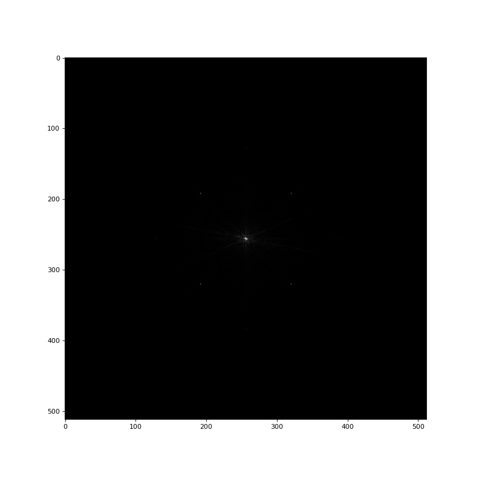

```python
%matplotlib notebook
# load BW image
img = cv2.imread('./data/Cameraman_PeriodicNoise.tif', 0) / 255.

n,m = img.shape

x,y = np.meshgrid(range(m), range(n))
centered_img = np.power(-1, x+y) * img

F = np.fft.fft2(centered_img)

# plt.imshow(np.log(np.abs(F)), cmap='gray')

Fdisplay=F.copy()
Fdisplay[int(m/2),int(n/2)]=0;
plt.figure()
plt.imshow(np.abs(Fdisplay),cmap='gray');
```

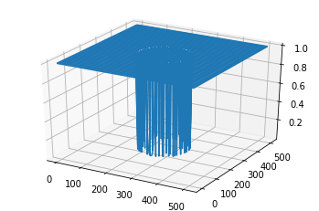

```python
%matplotlib inline
from mpl_toolkits.mplot3d import Axes3D as ax

# Noise frequencies which I manually identified above using the
# matplotlib notebook setting and hovering over with my mouse!
noise = np.array([[319.659, 322.519], [320.601,193.397], [191.565, 193.568], [192.507, 322.604]])
middlept = np.array([int(m/2),int(n/2)])

# choose D0 as average distance and w to ensure every noise pt is within w of the
# circle with radius D0 centered at the middlept
D0 = np.average(np.linalg.norm(noise-middlept, axis=-1))
maxerror = np.max(np.linalg.norm(noise-middlept, axis=-1) - D0)
w = 2 * np.abs(maxerror)

X,Y = np.meshgrid(range(m), range(n))
H = 1 - np.exp((-1 / 2.) * (((X-m/2.)**2 + (Y-n/2.)**2 - D0**2) / (w * np.sqrt((X - m/2.)**2 + (Y-n/2.)**2)))**2)

ax = plt.axes(projection='3d')
ax.plot_wireframe(X, Y, H)
```

**b.** Remove the noise using your filter by multiplying its transfer function by the DFT of the corrupted image and taking the inverse DFT of the result. (Be sure to implement proper centering and 'de-centering' as discussed below in Hints and Information.) In a single figure with four axes, show: i) the corrupted image, ii) your transfer function displayed as an image, iii) the filtered image, and iv) the difference between the two (with appropriately scaled intensity).

[figure not shown]

```python
x,y = np.meshgrid(range(m), range(n))
filtered = np.power(-1, x+y) * np.real(np.fft.ifft2(H * F))

plt.rcParams['figure.figsize'] = [15, 15]
plt.subplot(221, title='Corrupted image').imshow(img, cmap='gray')
plt.subplot(222, title='Transfer function').imshow(H, cmap='gray')
plt.subplot(223, title='Filtered image').imshow(filtered, cmap='gray')
plt.subplot(224, title='Difference').imshow(img-filtered, cmap='gray')
```

**c.** Display an image of the (centered) impulse response of your filter.

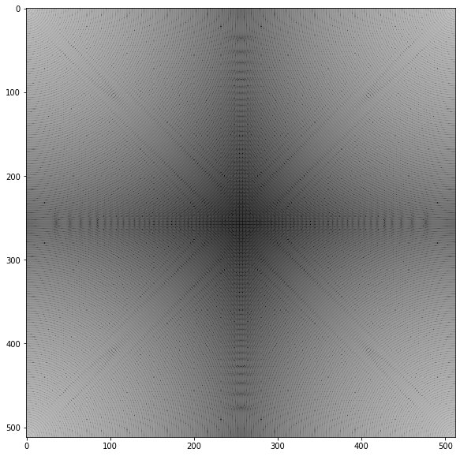

```python
impulse = np.fft.ifft2(H)

plt.rcParams['figure.figsize'] = [10, 10]
plt.imshow(np.log(np.abs(impulse)), cmap='gray')
```

**d.** Repeat part (b) using values of $w=20$ and $w=50$ in your transfer function. Does this noticeably affect your filtered image? How?

[figure not shown]

```python
w = 20
X,Y = np.meshgrid(range(m), range(n))
H = 1 - np.exp((-1 / 2.) * (((X-m/2.)**2 + (Y-n/2.)**2 - D0**2) / (w * np.sqrt((X - m/2.)**2 + (Y-n/2.)**2)))**2)
filtered20 = np.power(-1, x+y) * np.real(np.fft.ifft2(H * F))

w = 50
H = 1 - np.exp((-1 / 2.) * (((X-m/2.)**2 + (Y-n/2.)**2 - D0**2) / (w * np.sqrt((X - m/2.)**2 + (Y-n/2.)**2)))**2)
filtered50 = np.power(-1, x+y) * np.real(np.fft.ifft2(H * F))

w = 100
H = 1 - np.exp((-1 / 2.) * (((X-m/2.)**2 + (Y-n/2.)**2 - D0**2) / (w * np.sqrt((X - m/2.)**2 + (Y-n/2.)**2)))**2)
filtered100 = np.power(-1, x+y) * np.real(np.fft.ifft2(H * F))

plt.rcParams['figure.figsize'] = [15, 15]
plt.subplot(131, title='w = 20').imshow(filtered20, cmap='gray')
plt.subplot(132, title='w = 50').imshow(filtered50, cmap='gray')
plt.subplot(133, title='w = 100').imshow(filtered100, cmap='gray')
```

### Answer:

Yes it affects the filtered image. The image looks blurrier the bigger we make $w$! I tried it with $w=100$ too just for kicks.

## Hints and Information

The `scipy.optimize.least_squares` function can be used to iteratively minimize a sum of-squares objective function. A brief example (adapted from the online scipy documentation) is below. For further information, see the online documentation.

Suppose we want to find $\vx=(x_1,x_2)$ that minimizes

$ \sum_{k=1}^{10} f_k(\vx)^2=\sum_{k=1}^{10} \left(2+2k-e^{kx_1}-e^{kx_2}\right)^2. $

We write a function, let's call it `myfun` that takes a 2-vector $\vx$ and returns a ten-vector containing values for the ten functions $f_k$. That's all we have to do. By providing the `scipy.optimize.least_squares` function with a pointer to `my_fun` and an initial guess for `x`, the optimization toolbox will do the rest of the work, adjusting this initial guess and making repeated calls to `my_fun` until a (local) minimum in the objective function is found.

The function code is

```
def my_fun(x):
    k = np.linspace(1,10,10)
    F = 2 + 2*k - np.exp(k*x[0]) - np.exp(k*x[1]);
    return F
```

and this is fed to `scipy.optimize.least_squares` as in `scipy.optimize.least_squares(my_fun,np.array((0.3,0.4)))`, where the second argument is the initial 'guess' for `x`.

For the particular example in the bonus problem, your function `myfun` will be evaluating the objective function for a nine-element vector representing any 'guess' for the nine elements of the matrix $\mA$. Since the camera matrices are also required to compute the objective function (they are treated as constants and not optimized), they must also be given as input. Thus, your function will look like `myfun(A,M)`, and your call to `scipy.optimize.least_squares` will look something like

```
A = scipy.optimize.least_squares(my_fun,np.reshape(np.eye(3,3),(-1,9)),args=([M]))
A = A.x.reshape((3,3))
```

where the identity matrix is being used for the initial guess. Again, see the online documentation for further details.

To compute the DFT and inverse DFT in python, use the commands `np.fft.fft2` and `np.fft.ifft2`. Note that images must be converted to class `double` (by dividing by 255) before being used as input to `np.fft.fft2`. Appropriate centering is accomplished using the `np.meshgrid` command to generate arrays of $x$ and $y$ coordinates, and then using a command of the form `np.power(-1,x+y)*im`, where `x` and `y` are the arrays generated by meshgrid. Given a complex valued DFT `F` its magnitude (or spectrum) is given by the command `np.abs(F)`. See the online numpy fft documentation for more information.

The DC component $F(0,0)$ of the DFT of an image is the average value of the image, and since an image is positive valued, this component tends to be very large. As a result, displaying the DFT using `plt.imshow(F,map='gray')` is not very informative. A more useful depiction is obtained by setting the DC component to zero prior to display. Here is some sample code assuming that `F` is the (centered) DFT of an image with width and height `M` and `N`

```
Fdisplay=F.copy()
Fdisplay[M/2,N/2]=0;
plt.figure()
plt.imshow(np.abs(Fdisplay),map='gray');
```

Filtering in the frequency domain with "centering" consists of these steps:

1. Multiply the input image by $(-1)^{x+y}$ to center the transform
2. Compute the DFT $F(u,v)$
3. Multiply $F(u,v)$ by the "filter transfer function" $H(u,v)$
4. Compute the inverse DFT
5. Obtain the real part
6. Multiply by $(-1)^{x+y}$